# Science Mapping Analysis with bibliometrix R-package: an example

Massimo Aria and Corrado Cuccurullo

June 19, 2020

# Bibliographic Collection

**Data source**: Clarivate Analytics Web of Science (http://apps.webofknowledge.com)

**Data format**: Plaintext

**Document Type**: Articles, letters, review and proceedings papers

# Install and load bibliometrix R-package

```r
# Stable version from CRAN (Comprehensive R Archive Network)
# if you need to execute the code, remove # from the beginning of the next line

# install.packages("bibliometrix")


# Most updated version from GitHub
# if you need to execute the code, remove # from the beginning of the next lines

# install.packages("devtools")
# devtools::install_github("massimoaria/bibliometrix")

library(bibliometrix)
```

# Data Loading and Converting

```r
# Converting the loaded files into a R bibliographic dataframe
#M <- convert2df(file=myfile, dbsource="scopus",format="bibtex")
M <- convert2df(file=myfile, dbsource="dimensions")
```

```
Converting your dimensions collection into a bibliographic dataframe
```

```
Error in gsub("\\.|-", " ", names(DATA)) : objeto 'DATA' não encontrado
```

# Section 1: Descriptive Analysis

Although bibliometrics is mainly known for quantifying the scientific production and measuring its quality and impact, it is also useful for displaying and analysing the intellectual, conceptual and social structures of research as well as their evolution and dynamical aspects.

In this way, bibliometrics aims to describe how specific disciplines, scientific domains, or research fields are structured and how they evolve over time. In other words, bibliometric methods help to map the science (so-called science mapping) and are very useful in the case of research synthesis, especially for the systematic ones.

Bibliometrics is an academic science founded on a set of statistical methods, which can be used to analyze scientific big data quantitatively and their evolution over time and discover information. Network structure is often used to model the interaction among authors, papers/documents/articles, references, keywords, etc.

Bibliometrix is an open-source software for automating the stages of data-analysis and data-visualization. After converting and uploading bibliographic data in R, Bibliometrix performs a descriptive analysis and different research-structure analysis.

Descriptive analysis provides some snapshots about the annual research development, the top “k” productive authors, papers, countries and most relevant keywords.

## Main findings about the collection

```r
summary(results, k=10, pause=F, width=130)
```

```
MAIN INFORMATION ABOUT DATA

 Timespan                              1966 : 2021
 Sources (Journals, Books, etc)        1361
 Documents                             5548
 Average years from publication        9.4
 Average citations per documents       17.59
 Average citations per year per doc    Inf
 References                            161480

DOCUMENT TYPES
 article                         3886
 article; book chapter           3
 article; data paper             1
 article; early access           101
 article; proceedings paper      1429
 review                          121
 review; book chapter            4
 review; early access            3

DOCUMENT CONTENTS
 Keywords Plus (ID)                    4595
 Author's Keywords (DE)                12202

AUTHORS
 Authors                               14117
 Author Appearances                    19317
 Authors of single-authored documents  600
 Authors of multi-authored documents   13517

AUTHORS COLLABORATION
 Single-authored documents             668
 Documents per Author                  0.393
 Authors per Document                  2.54
 Co-Authors per Documents              3.48
 Collaboration Index                   2.77


Annual Scientific Production
```

| Year | Articles |
| --- | --- |
| 1966 | 1 |
| 1972 | 1 |
| 1973 | 2 |
| 1976 | 2 |
| 1977 | 1 |
| 1979 | 2 |
| 1980 | 1 |
| 1981 | 2 |
| 1983 | 1 |
| 1984 | 1 |

[output cut: 37 more lines]

```
Annual Percentage Growth Rate 2.969486


Most Productive Authors
```

|  | Authors | Articles | Authors | Articles Fractionalized |
| --- | --- | --- | --- | --- |
| 1 | ZHANG Y | 30 | ZHANG Y | 7.78 |
| 2 | ZHANG J | 23 | LUKASIEWICZ T | 7.73 |
| 3 | SHAO L | 22 | OGIELA MR | 6.83 |
| 4 | YANG Y | 21 | TADEUSIEWICZ R | 6.83 |
| 5 | LI Y | 19 | JUNG JJ | 6.25 |
| 6 | KIM J | 18 | WANG YX | 5.94 |
| 7 | WANG J | 18 | HUSSAIN FK | 5.75 |
| 8 | LI J | 17 | ZHANG J | 5.41 |
| 9 | OGIELA MR | 17 | SAMSONOVICH AV | 5.33 |
| 10 | TADEUSIEWICZ R | 17 | WANG J | 5.14 |

```
Top manuscripts per citations
```

|  | Paper | TC | TCperYear |
| --- | --- | --- | --- |
| 1 | SMEULDERS AWM, 2000, IEEE T PATTERN ANAL | 3303 | 157.3 |
| 2 | CHEN LC, 2018, IEEE T PATTERN ANAL | 2159 | 719.7 |
| 3 | BADRINARAYANAN V, 2017, IEEE T PATTERN ANAL | 1945 | 486.2 |
| 4 | SHELHAMER E, 2017, IEEE T PATTERN ANAL | 1560 | 390.0 |
| 5 | KANE MJ, 2002, PSYCHON B REV | 1225 | 64.5 |
| 6 | WANG JZ, 2001, IEEE T PATTERN ANAL | 1125 | 56.2 |
| 7 | HERRERA F, 2000, FUZZY SET SYST | 1073 | 51.1 |
| 8 | RESNIK P, 1999, J ARTIF INTELL RES | 973 | 44.2 |
| 9 | TURNEY PD, 2010, J ARTIF INTELL RES | 886 | 80.5 |
| 10 | TORRALBA A, 2008, IEEE T PATTERN ANAL | 783 | 60.2 |

```
Corresponding Author's Countries
```

|  | Country | Articles | Freq | SCP | MCP | MCP_Ratio |
| --- | --- | --- | --- | --- | --- | --- |
| 1 | CHINA | 1117 | 0.2062 | 815 | 302 | 0.270 |
| 2 | USA | 863 | 0.1593 | 709 | 154 | 0.178 |
| 3 | SPAIN | 351 | 0.0648 | 271 | 80 | 0.228 |
| 4 | UNITED KINGDOM | 328 | 0.0605 | 230 | 98 | 0.299 |
| 5 | GERMANY | 301 | 0.0556 | 232 | 69 | 0.229 |
| 6 | ITALY | 282 | 0.0520 | 218 | 64 | 0.227 |
| 7 | FRANCE | 198 | 0.0365 | 142 | 56 | 0.283 |
| 8 | AUSTRALIA | 160 | 0.0295 | 101 | 59 | 0.369 |
| 9 | CANADA | 158 | 0.0292 | 119 | 39 | 0.247 |
| 10 | KOREA | 157 | 0.0290 | 129 | 28 | 0.178 |

```
SCP: Single Country Publications

MCP: Multiple Country Publications


Total Citations per Country
```

|  | Country | Total Citations | Average Article Citations |
| --- | --- | --- | --- |
| 1 | USA | 29534 | 34.22 |
| 2 | UNITED KINGDOM | 8613 | 26.26 |
| 3 | CHINA | 8084 | 7.24 |
| 4 | SPAIN | 6490 | 18.49 |
| 5 | ITALY | 5510 | 19.54 |
| 6 | NETHERLANDS | 5482 | 55.94 |
| 7 | CANADA | 4558 | 28.85 |
| 8 | GERMANY | 4472 | 14.86 |
| 9 | AUSTRALIA | 2969 | 18.56 |
| 10 | FRANCE | 2773 | 14.01 |

```
Most Relevant Sources
```

|  | Sources | Articles |
| --- | --- | --- |
| 1 | IEEE TRANSACTIONS ON PATTERN ANALYSIS AND MACHINE INTELLIGENCE | 171 |
| 2 | ARTIFICIAL INTELLIGENCE | 131 |
| 3 | ENGINEERING APPLICATIONS OF ARTIFICIAL INTELLIGENCE | 111 |
| 4 | APPLIED INTELLIGENCE | 97 |
| 5 | JOURNAL OF AMBIENT INTELLIGENCE AND HUMANIZED COMPUTING | 96 |
| 6 | IEEE ACCESS | 93 |
| 7 | JOURNAL OF ARTIFICIAL INTELLIGENCE RESEARCH | 75 |
| 8 | ARTIFICIAL INTELLIGENCE IN MEDICINE | 73 |
| 9 | COMPUTATIONAL INTELLIGENCE | 68 |
| 10 | INTERNATIONAL JOURNAL OF PATTERN RECOGNITION AND ARTIFICIAL INTELLIGENCE | 68 |

```
Most Relevant Keywords
```

|  | Author Keywords (DE) | Articles | Keywords-Plus (ID) | Articles |
| --- | --- | --- | --- | --- |
| 1 | SEMANTIC WEB | 234 | MODEL | 211 |
| 2 | ONTOLOGY | 208 | INTELLIGENCE | 176 |
| 3 | ARTIFICIAL INTELLIGENCE | 190 | INFORMATION | 154 |
| 4 | SEMANTIC | 167 | SYSTEM | 136 |
| 5 | SEMANTICS | 160 | CLASSIFICATION | 132 |
| 6 | DEEP LEARNING | 145 | KNOWLEDGE | 131 |
| 7 | MACHINE LEARNING | 100 | RECOGNITION | 120 |
| 8 | ONTOLOGIES | 97 | FRAMEWORK | 116 |
| 9 | LEARNING | 95 | REPRESENTATION | 116 |
| 10 | NATURAL LANGUAGE PROCESSING | 93 | ONTOLOGY | 106 |

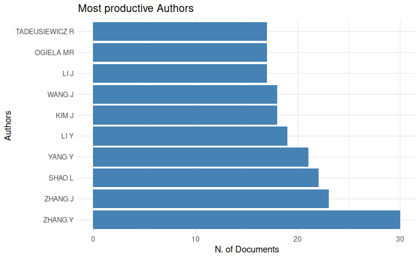

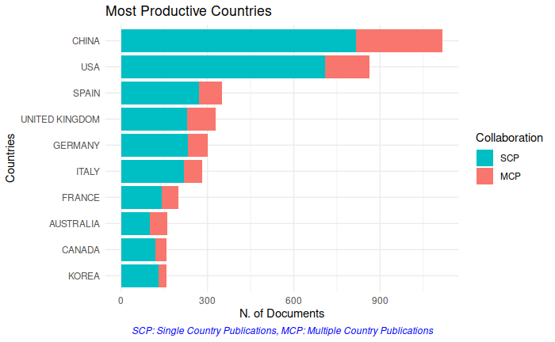

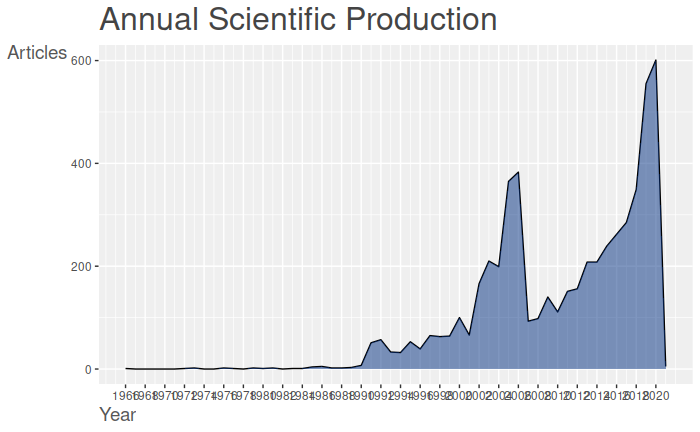

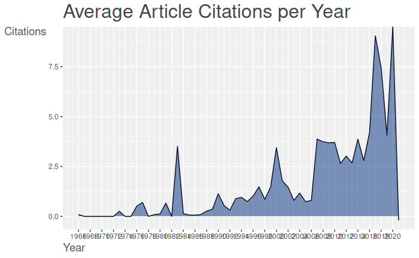

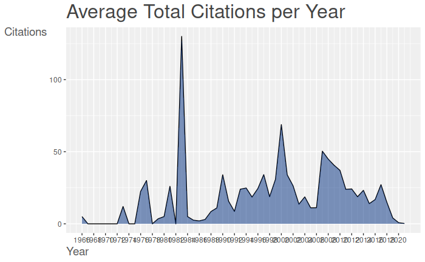

```r
plot(x=results, k=10, pause=F)
```

## Most Cited References

```r
CR <- citations(M, field = "article", sep = ";")
cbind(CR$Cited[1:30])
```

```
                                                                                                                                  [,1]
BERNERS-LEE T, 2001, SCI AM, V284, P34, DOI 10.1038/SCIENTIFICAMERICAN0501-34                                                      212
BLEI DM, 2003, J MACH LEARN RES, V3, P993, DOI 10.1162/JMLR.2003.3.4-5.993                                                         156
KAIMING HE, 2016, 2016 IEEE CONFERENCE ON COMPUTER VISION AND PATTERN RECOGNITION (CVPR), P770, DOI 10.1109/CVPR.2016.90           144
MILLER GA, 1995, COMMUN ACM, V38, P39, DOI 10.1145/219717.219748                                                                   144
LONG JONATHAN, 2015, 2015 IEEE CONFERENCE ON COMPUTER VISION AND PATTERN RECOGNITION (CVPR), P3431, DOI 10.1109/CVPR.2015.7298965  139
FELLBAUM C, 1998, WORDNET ELECT LEXICA                                                                                             134
KRIZHEVSKY A., 2012, ADV NEURAL INFORM PR, P1097, DOI DOI 10.1145/3065386                                                          131
DEERWESTER S, 1990, J AM SOC INFORM SCI, V41, P391, DOI 10.1002/(SICI)1097-4571(199009)41:6<391::AID-ASI1>3.0.CO                   129
MIKOLOV T, 2013, ADV NEURAL INFORM PR, P3111, DOI DOI 10.1162/JMLR.2003.3.4-5.951                                                  127
GRUBER TR, 1993, KNOWL ACQUIS, V5, P199, DOI 10.1006/KNAC.1993.1008                                                                124
SZEGEDY C, 2015, PROC CVPR IEEE, P1, DOI 10.1109/CVPR.2015.7298594                                                                 107
BAADER F, 2003, DESCRIPTION LOGIC HD                                                                                               106
LOWE DG, 2004, INT J COMPUT VISION, V60, P91, DOI 10.1023/B:VISI.0000029664.99615.94                                               103
KRIZHEVSKY A, 2017, COMMUN ACM, V60, P84, DOI 10.1145/3065386                                                                      100
DENG J, 2009, PROC CVPR IEEE, P248, DOI 10.1109/CVPRW.2009.5206848                                                                  98
REN SQ, 2015, ADV NEUR IN, V28, DOI 10.1109/TPAMI.2016.2577031                                                                      98
HOCHREITER S, 1997, NEURAL COMPUT, V9, P1735, DOI 10.1162/NECO.1997.9.8.1735                                                        97
HE KM, 2016, PROC CVPR IEEE, P770, DOI [10.1109/CVPR.2016.90, 10.1109/TIE.2018.2870413, 10.1109/CVPR.2017.563]                      95
PENNINGTON J., 2014, P EMNLP C, P1532, DOI DOI 10.3115/V1/D14-1162                                                                  93
RONNEBERGER O, 2015, LECT NOTES COMPUT SC, V9351, P234, DOI 10.1007/978-3-319-24574-4_28                                            88
SIMONYAN K., 2014, 14091556 ARXIV, DOI DOI 10.1109/ACPR.2015.7486599                                                                83
LANDAUER TK, 1997, PSYCHOL REV, V104, P211, DOI 10.1037/0033-295X.104.2.211                                                         81
ZADEH LA, 1965, INFORM CONTROL, V8, P338, DOI 10.1016/S0019-9958(65)90241-X                                                         79
RUSSAKOVSKY O, 2015, INT J COMPUT VISION, V115, P211, DOI 10.1007/S11263-015-0816-Y                                                 75
LECUN Y, 2015, NATURE, V521, P436, DOI 10.1038/NATURE14539                                                                          74
LIN TY, 2014, LECT NOTES COMPUT SC, V8693, P740, DOI 10.1007/978-3-319-10602-1_48                                                   73
LANDAUER TK, 1998, DISCOURSE PROCESS, V25, P259, DOI 10.1080/01638539809545028                                                      72
RESNIK P, 1995, INT JOINT CONF ARTIF, P448                                                                                          72
GIRSHICK R, 2014, PROC CVPR IEEE, P580, DOI 10.1109/CVPR.2014.81                                                                    70
CHEN LC, 2018, IEEE T PATTERN ANAL, V40, P834, DOI 10.1109/TPAMI.2017.2699184                                                       66
```

# Section 2: The Intellectual Structure of the field - Co-citation Analysis

Citation analysis is one of the main classic techniques in bibliometrics. It shows the structure of a specific field through the linkages between nodes (e.g. authors, papers, journal), while the edges can be differently interpretated depending on the network type, that are namely co-citation, direct citation, bibliographic coupling. Please see Aria, Cuccurullo (2017).

Below there are three examples.

The useful dimensions to comment the co-citation networks are: (i) centrality and peripherality of nodes, (ii) their proximity and distance, (iii) strength of ties, (iv) clusters, (iiv) bridging contributions.

Third, a historiograph is built on direct citations. It draws the intellectual linkages in a historical order. Cited works of thousands of authors contained in a collection of published scientific articles is sufficient for recostructing the historiographic structure of the field, calling out the basic works in it.

**Plot options**:

[figure not shown]

```r
#netstat <- networkStat(NetMatrix)
#summary(netstat,k=10)
```

## Journal (Source) co-citation analysis

```r
M=metaTagExtraction(M,"CR_SO",sep=";")
NetMatrix <- biblioNetwork(M, analysis = "co-citation", network = "sources", sep = ";")
```

```
Error in strsplit(M[, Field], sep) : argumento modo não caractere
```

Descriptive analysis of Journal co-citation network characteristics

```r
netstat <- networkStat(NetMatrix)
summary(netstat,k=10)
```

[output not shown]

# Section 3: Historiograph - Direct citation linkages

```r
histResults <- histNetwork(M, min.citations=quantile(M$TC,0.75), sep = ";")
```

```
WOS DB:
Searching local citations (LCS) by reference items (SR) and DOIs...

Analyzing 145599 reference items...

Found 614 documents with no empty Local Citations (LCS)
```

```
 Legend
```

| Label | Year | LCS | GCS |
| --- | --- | --- | --- |
| FROMM D, 1991, CORTEX DOI 10.1016/S0010-9452(13)80032-9 | 1991 | 6 | 60 |
| SCHAIE KW, 1993, PSYCHOL AGING DOI 10.1037/0882-7974.8.1.44 | 1993 | 5 | 81 |
| NYBERG L, 1996, J GERONTOL B-PSYCHOL DOI 10.1093/GERONB/51B.4.P234 | 1996 | 4 | 87 |
| NILSSON LG, 1997, AGING NEUROPSYCHOL C DOI 10.1080/13825589708256633 | 1997 | 7 | 358 |
| SCHMAND B, 1998, J CLIN EXP NEUROPSYC DOI 10.1076/JCEN.20.1.42.1485 | 1998 | 5 | 49 |
| ANOKHIN AP, 1999, INT J PSYCHOPHYSIOL DOI 10.1016/S0167-8760(99)00064-1 | 1999 | 5 | 100 |
| WALTZ JA, 1999, PSYCHOL SCI DOI 10.1111/1467-9280.00118 | 1999 | 11 | 281 |
| MAITLAND SB, 2000, AGING NEUROPSYCHOL C DOI 10.1076/ANEC.7.1.32.807 | 2000 | 4 | 62 |
| JAUSOVEC N, 2000, BRAIN TOPOGR DOI 10.1023/A:1023446024923 | 2000 | 5 | 62 |
| STANKOV L, 2000, INTELLIGENCE DOI 10.1016/S0160-2896(99)00033-1 | 2000 | 12 | 120 |

[output cut: 27 more lines]

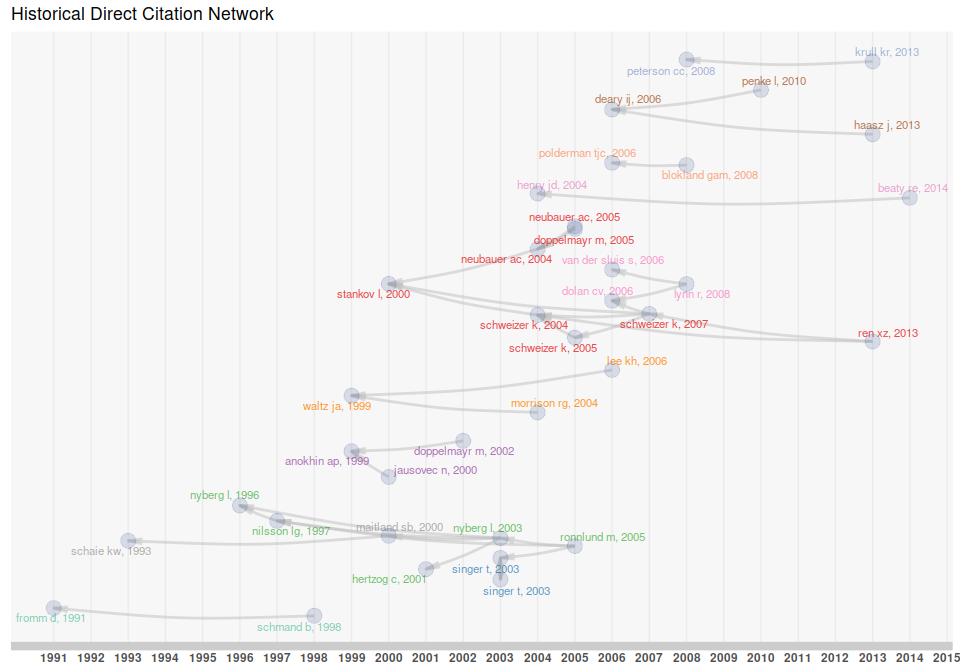

```r
options(width = 130)
net <- histPlot(histResults, n=50, size = 5, labelsize = 3)
```

# Section 4: The conceptual structure - Co-Word Analysis

Co-word networks show the conceptual structure, that uncovers links between concepts through term co-occurences.

Conceptual structure is often used to understand the topics covered by scholars (so-called research front) and identify what are the most important and the most recent issues.

Dividing the whole timespan in different timeslices and comparing the conceptual structures is useful to analyze the evolution of topics over time.

Bibliometrix is able to analyze keywords, but also the terms in the articles’ titles and abstracts. It does it using network analysis or correspondance analysis (CA) or multiple correspondance analysis (MCA). CA and MCA visualise the conceptual structure in a two-dimensional plot.

## Co-word Analysis through Keyword co-occurrences

```r
net2VOSviewer(net)
```

```
VOSviewer.jar does not exist in the path /home/tbnsilveira/Documentos/phd/atividades de pesquisa/bibliometry_WoS Inteligence and Semantic

Plese download it from http://www.vosviewer.com/download
(Java version for other systems)
```

Descriptive analysis of keyword co-occurrences network characteristics

```r
netstat <- networkStat(NetMatrix)
summary(netstat,k=10)
```

```
Main statistics about the network

 Size                                  5838
 Density                               0.003
 Transitivity                          0.096
 Diameter                              6
 Degree Centralization                 0.26
 Average path length                   2.808
```

## Co-word Analysis through Correspondence Analysis

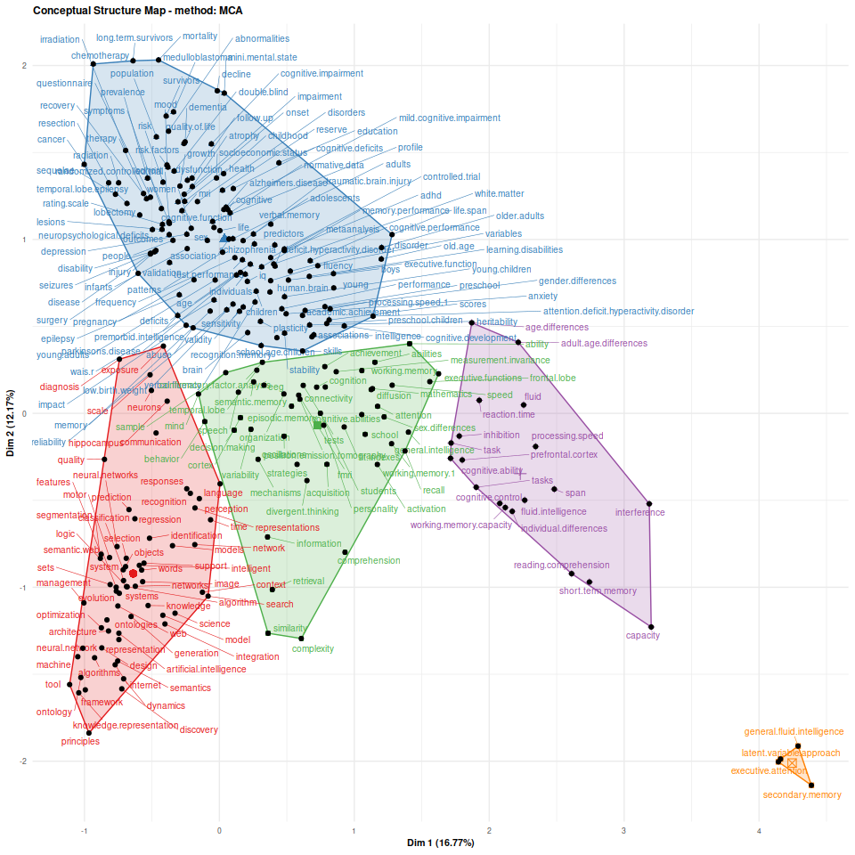

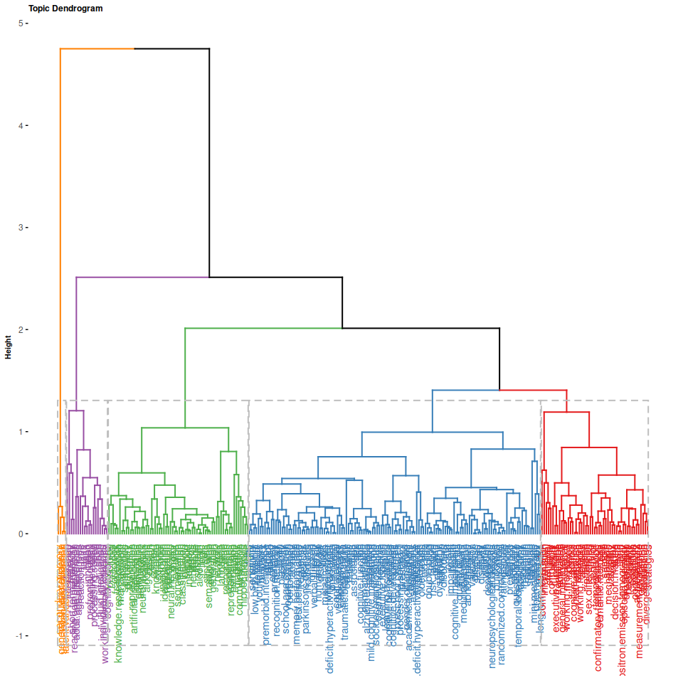

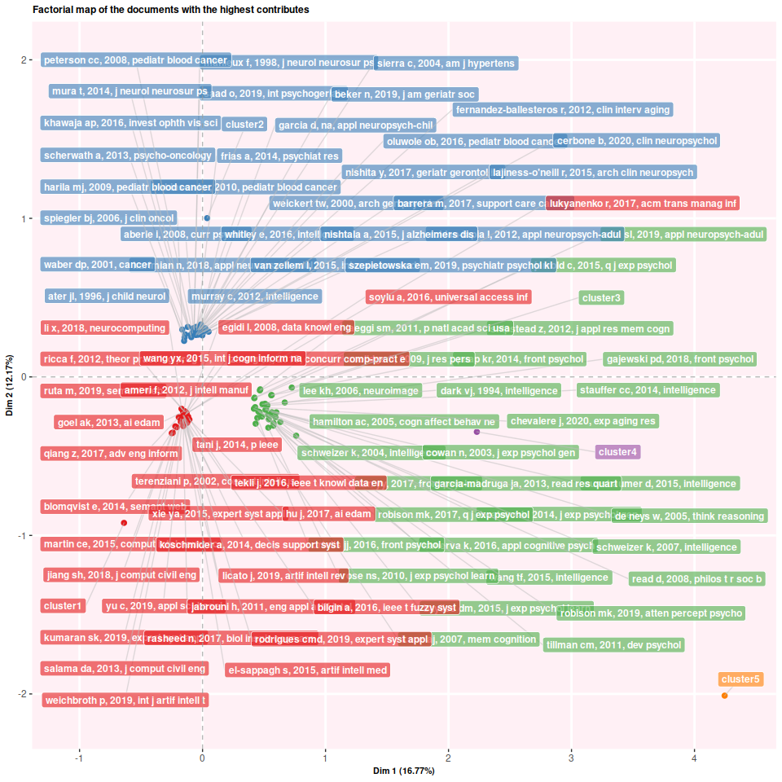

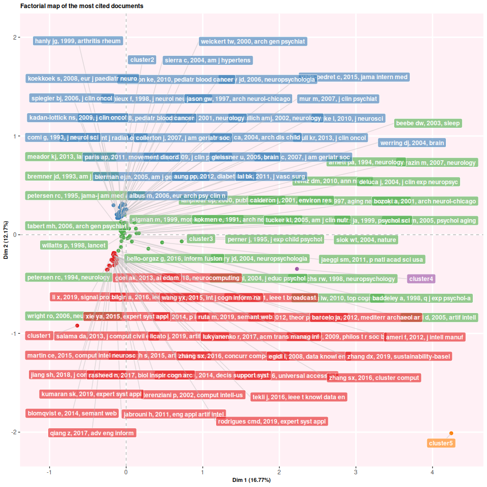

```r
CS <- conceptualStructure(M, method="MCA", field="ID", minDegree=10, clust=5, stemming=FALSE, labelsize=8,documents=30)
```

# Section 5: Thematic Map

Co-word analysis draws clusters of keywords. They are considered as themes, whose density and centrality can be used in classifying themes and mapping in a two-dimensional diagram.

Thematic map is a very intuitive plot and we can analyze themes according to the quadrant in which they are placed: (1) upper-right quadrant: motor-themes; (2) lower-right quadrant: basic themes; (3) lower-left quadrant: emerging or disappearing themes; (4) upper-left quadrant: very specialized/niche themes.

Please see Cobo, M. J., L?pez-Herrera, A. G., Herrera-Viedma, E., & Herrera, F. (2011). An approach for detecting, quantifying, and visualizing the evolution of a research field: A practical application to the fuzzy sets theory field. Journal of Informetrics, 5(1), 146-166.

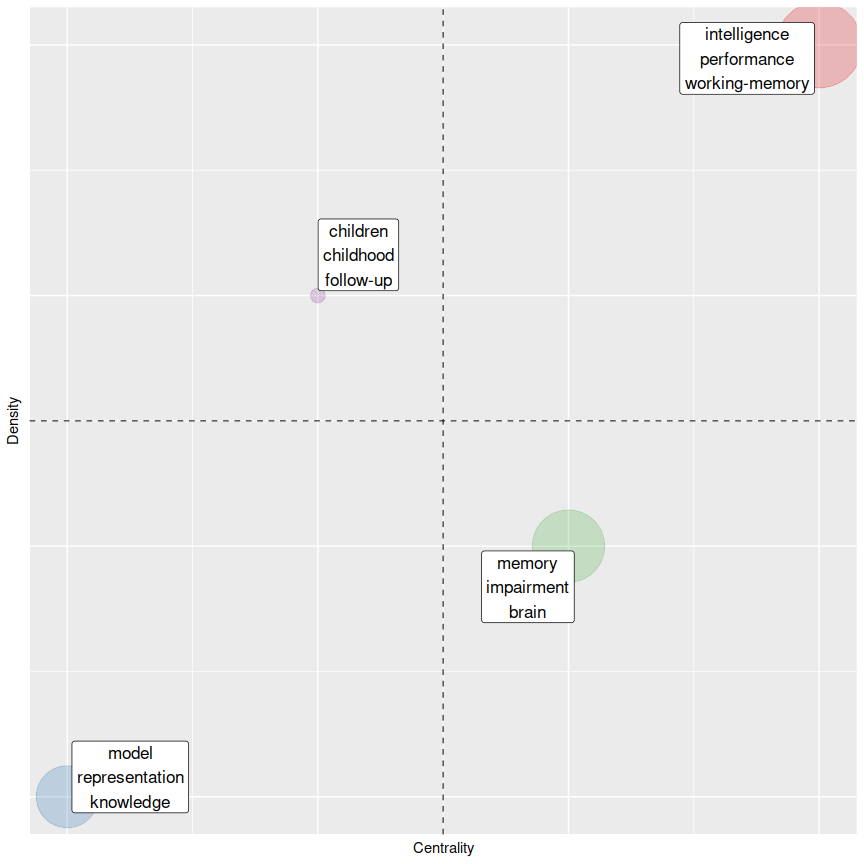

```r
Map=thematicMap(M, field = "ID", n = 250, minfreq = 5,
  stemming = FALSE, size = 0.5, n.labels=3, repel = TRUE)
plot(Map$map)
```

Cluster description

```r
Clusters=Map$words[order(Map$words$Cluster,-Map$words$Occurrences),]
library(dplyr)
CL <- Clusters %>% group_by(.data$Cluster_Label) %>% top_n(5, .data$Occurrences)
CL
```

| Occurrences | Words | Cluster | Color | Cluster_Label |
| --- | --- | --- | --- | --- |
| 432 | intelligence | 1 | #E41A1C80 | intelligence |
| 303 | performance | 1 | #E41A1C80 | intelligence |
| 287 | working-memory | 1 | #E41A1C80 | intelligence |
| 148 | individual-differences | 1 | #E41A1C80 | intelligence |
| 109 | attention | 1 | #E41A1C80 | intelligence |
| 123 | model | 2 | #377EB880 | model |
| 109 | representation | 2 | #377EB880 | model |
| 91 | knowledge | 2 | #377EB880 | model |
| 88 | system | 2 | #377EB880 | model |
| 84 | information | 2 | #377EB880 | model |

[output cut: 10 more lines]

# Section 6: The social structure - Collaboration Analysis

## Author collaboration network

```r
NetMatrix <- biblioNetwork(M, analysis = "collaboration",  network = "authors", sep = ";")
net=networkPlot(NetMatrix,  n = 50, Title = "Author collaboration",type = "auto", size=10,size.cex=T,edgesize = 3,labelsize=0.6)
```

[output not shown]

Descriptive analysis of author collaboration network characteristics

```r
netstat <- networkStat(NetMatrix)
summary(netstat,k=15)
```

```
Main statistics about the network

 Size                                  11563
 Density                               0.001
 Transitivity                          0.859
 Diameter                              22
 Degree Centralization                 0.008
 Average path length                   8.201
```

## Edu collaboration network

```r
NetMatrix <- biblioNetwork(M, analysis = "collaboration",  network = "universities", sep = ";")
net=networkPlot(NetMatrix,  n = 50, Title = "Edu collaboration",type = "auto", size=10,size.cex=T,edgesize = 3,labelsize=0.6)
```

[output not shown]

Descriptive analysis of edu collaboration network characteristics

```r
netstat <- networkStat(NetMatrix)
summary(netstat,k=15)
```

```
Main statistics about the network

 Size                                  3047
 Density                               0.001
 Transitivity                          0.356
 Diameter                              13
 Degree Centralization                 0.026
 Average path length                   4.872
```

## Country collaboration network

```r
M <- metaTagExtraction(M, Field = "AU_CO", sep = ";")
NetMatrix <- biblioNetwork(M, analysis = "collaboration",  network = "countries", sep = ";")
net=networkPlot(NetMatrix,  n = dim(NetMatrix)[1], Title = "Country collaboration",type = "circle", size=10,size.cex=T,edgesize = 1,labelsize=0.6, cluster="none")
```

[output not shown]

Descriptive analysis of country collaboration network characteristics

```r
netstat <- networkStat(NetMatrix)
summary(netstat,k=15)
```

```
Main statistics about the network

 Size                                  100
 Density                               0.087
 Transitivity                          0.36
 Diameter                              5
 Degree Centralization                 0.559
 Average path length                   2.231
```